# Esempio1_Es4

# 1 TESTO

Il dataset mammiferi.csv contiene i dati relativi al peso del cervello e del corpo di 62 specie di mammiferi. Il peso del cervello è espresso in grammi, mentre il peso del corpo in chilogrammi.

Si risponda ai seguenti quesiti:

1. si costruisca un modello per prevedere il peso del cervello di un mammifero sulla base del peso del suo corpo;
2. si illustri il modello calcolando un intervallo di previsione al 90% per il peso del cervello di un mammifero di (i) 50 chilogrammi e (ii) 100 chilogrammi.

# 2 SOLUZIONE

## 2.1 Punto 1

Leggiamo e visualizziamo i dati:

```r
mammiferi <- read.csv("mammiferi.csv")
head(mammiferi)
```

|  | specie | cervello | corpo |
| --- | --- | --- | --- |
| 1 | Africanelephant | 5712.0 | 6654.000 |
| 2 | Africangiantpouchedrat | 6.6 | 1.000 |
| 3 | ArcticFox | 44.5 | 3.385 |
| 4 | Arcticgroundsquirrel | 5.7 | 0.920 |
| 5 | Asianelephant | 4603.0 | 2547.000 |
| 6 | Baboon | 179.5 | 10.550 |

Visualizzo i dati tramite grafico:

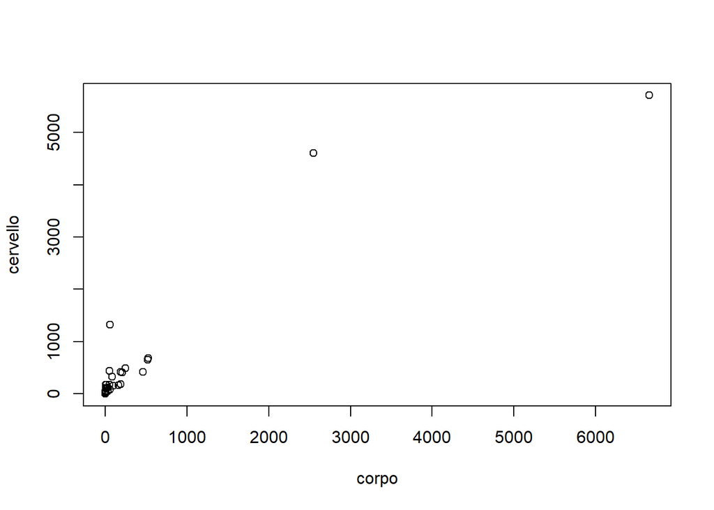

```r
plot(cervello ~ corpo, data = mammiferi)
```

Noto che il grafico non è di facile interpretazione a causa di due valori. Stimiamo la retta di regressione:

```r
mod <- lm(cervello ~ corpo, data = mammiferi)
summary(mod)
```

```
##
## Call:
## lm(formula = cervello ~ corpo, data = mammiferi)
##
## Residuals:
##     Min      1Q  Median      3Q     Max
## -810.07  -88.52  -79.64  -13.02 2050.33
##
## Coefficients:
##             Estimate Std. Error t value Pr(>|t|)
## (Intercept) 91.00440   43.55258    2.09   0.0409 *
## corpo        0.96650    0.04766   20.28   <2e-16 ***
## ---
## Signif. codes:  0 '***' 0.001 '**' 0.01 '*' 0.05 '.' 0.1 ' ' 1
##
## Residual standard error: 334.7 on 60 degrees of freedom
## Multiple R-squared:  0.8727, Adjusted R-squared:  0.8705
## F-statistic: 411.2 on 1 and 60 DF,  p-value: < 2.2e-16
```

Analizzo i residui:

```r
library(car)
```

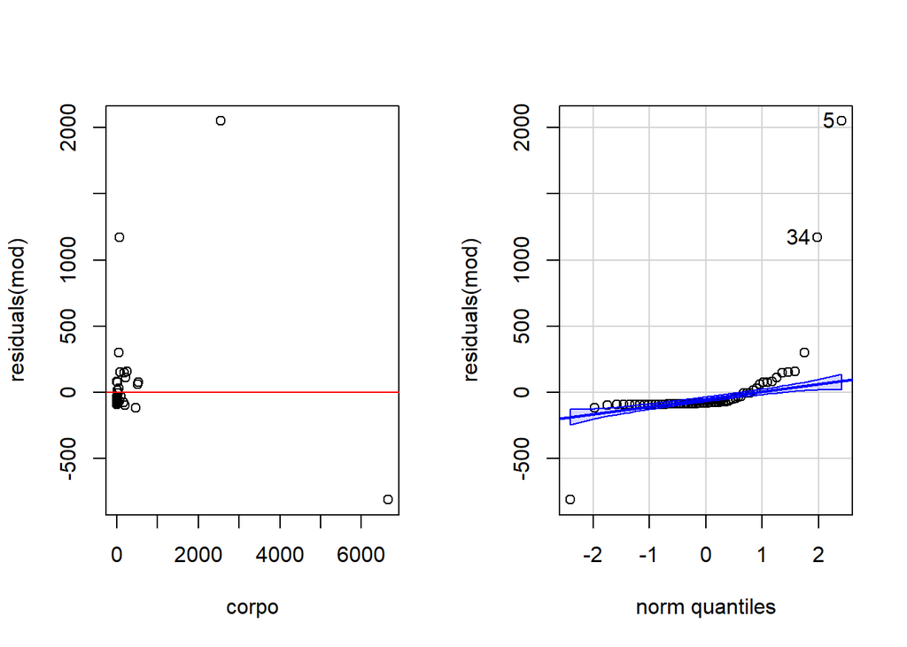

```
## [1]  5 34
```

```r
par(mfrow = c(1, 2))
plot(residuals(mod) ~ corpo, data = mammiferi)
abline(h = 0, col = "red")
qqPlot(residuals(mod))
```

L’analisi dei residui mostra che il modello di regressione non è appropriato.

Provo a trasformare le variabili su scala logaritmica:

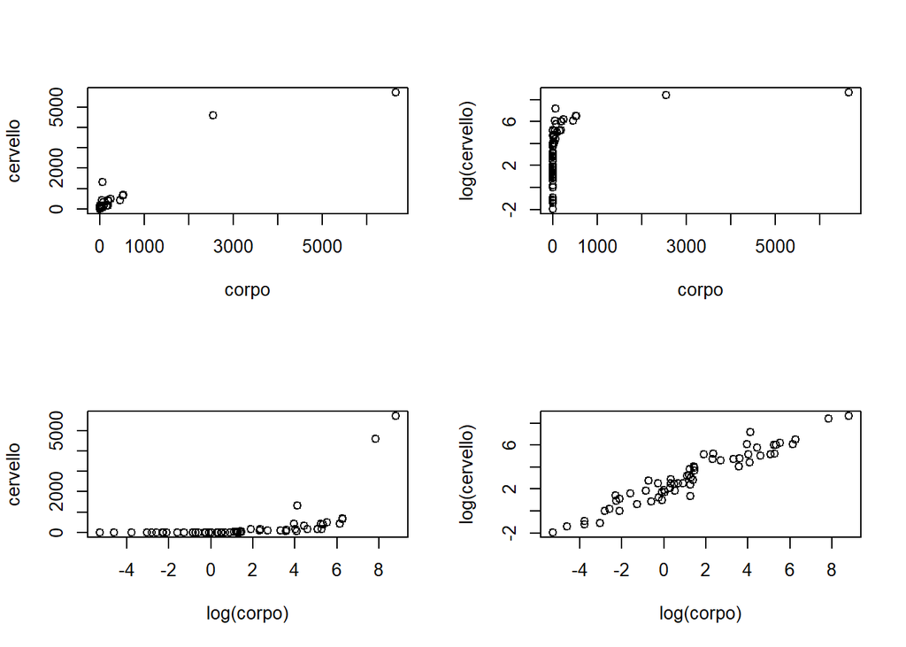

```r
par(mfrow = c(2, 2))
plot(cervello ~ corpo, data = mammiferi)
plot(log(cervello) ~ corpo, data = mammiferi)
plot(cervello ~ log(corpo), data = mammiferi)
plot(log(cervello) ~ log(corpo), data = mammiferi)
```

Vedo che il quarto grafico è il migliore. Costruisco il modello:

```r
mod_log <- lm(log(cervello) ~ log(corpo), data = mammiferi)
summary(mod_log)
```

```
##
## Call:
## lm(formula = log(cervello) ~ log(corpo), data = mammiferi)
##
## Residuals:
##      Min       1Q   Median       3Q      Max
## -1.71550 -0.49228 -0.06162  0.43597  1.94829
##
## Coefficients:
##             Estimate Std. Error t value Pr(>|t|)
## (Intercept)  2.13479    0.09604   22.23   <2e-16 ***
## log(corpo)   0.75169    0.02846   26.41   <2e-16 ***
## ---
## Signif. codes:  0 '***' 0.001 '**' 0.01 '*' 0.05 '.' 0.1 ' ' 1
##
## Residual standard error: 0.6943 on 60 degrees of freedom
## Multiple R-squared:  0.9208, Adjusted R-squared:  0.9195
## F-statistic: 697.4 on 1 and 60 DF,  p-value: < 2.2e-16
```

Il modello stimato spiega:

- il 92% della variabilità del peso del cervello dei mammiferi su scala logaritmica;
- indica che il logaritmo del peso del corpo è un predittore fortemente significativo del logaritmo del peso del cervello e che la relazione è crescente.

Visualizziamo il modello stimato:

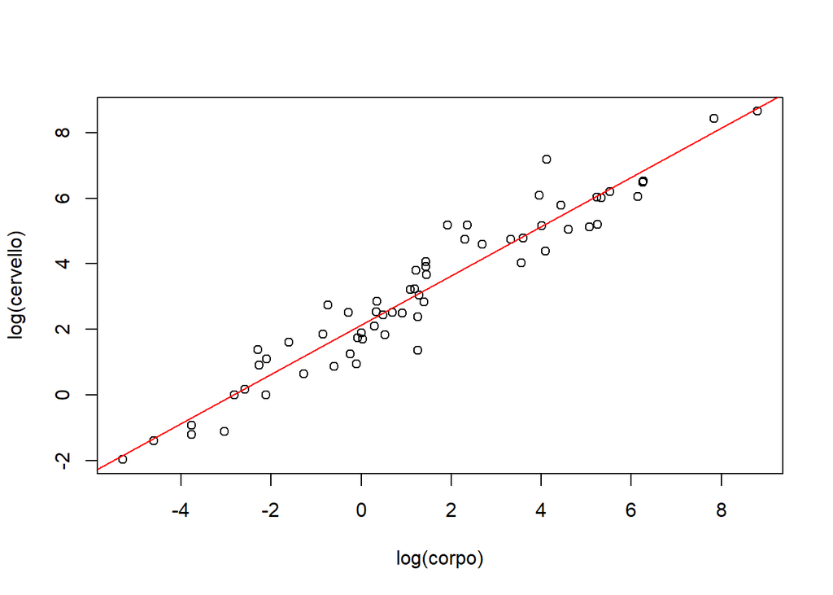

```r
plot(log(cervello) ~ log(corpo), data = mammiferi)
abline(mod_log, col = "red")
```

Il grafico suggerisce che la retta di regressione è adeguata per descrivere la relazione tra il logaritmo del peso del cervello e il logaritmo del peso del corpo.

L’analisi dei residui è ora soddisfacente:

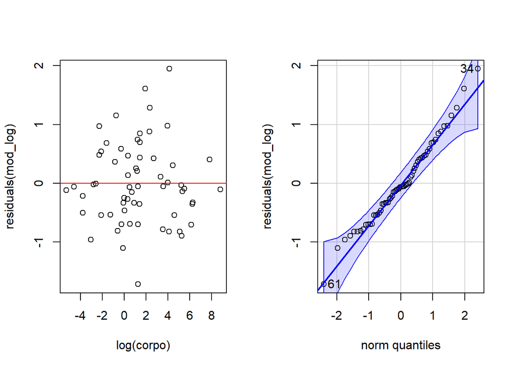

```
## [1] 34 61
```

```r
par(mfrow = c(1, 2))
plot(residuals(mod_log) ~ log(corpo), data = mammiferi)
abline(h = 0, col = "red")
qqPlot(residuals(mod_log))
```

## 2.2 Punto 2

Calcoliamo l’intervallo di previsione al 90% per il peso del cervello di un mammifero di 50 chilogrammi:

```r
pred <- predict(mod_log, newdata = data.frame(corpo = 50), interval = "prediction", level = 0.90)
exp(pred)
```

```
##        fit     lwr      upr
## 1 160.0364 49.3911 518.5479
```

Se il mammifero pesasse 100 chilogrammi:

```r
pred <- predict(mod_log, newdata = data.frame(corpo = 100), interval = "prediction", level = 0.90)
exp(pred)
```

```
##        fit      lwr      upr
## 1 269.4628 82.84002 876.5112
```